# Ski Pass Exploratory

Winston Saunders

March 26, 2015

## Download Data from Pass MBXXXXXXXX

Data are extracted from the [Track Your Turns](http://track.mtbachelor.com/index.asp) website at [Mt. Bachelor](http://www.mtbachelor.com/site). For this particular pass there are 2700 total runs.

Let’s look at a sample of the ski runs data:

```r
print_sample<-sort(sample(1:dim(ski_runs)[1], 8))
print(ski_runs[print_sample,2:8])
```

```
##            chair vertical_feet vertical_meters year month day time_of_day
## 143  Pine Marten          1367             416 2006     3  18    13:36:00
## 235      Sunrise           808             246 2006    12  16    12:57:00
## 840  Pine Marten          1367             416 2009     1  14    10:26:00
## 1428      Summit          1709             520 2010     2  27    10:56:16
## 1982    Skyliner          1306             398 2012     3  11    09:05:37
## 1983     Sunrise           808             246 2012     3  11    09:28:34
## 1993     Rainbow          1209             368 2012     3  24    09:57:26
## 2333     Outback          1780             542 2013     3  24    10:29:45
```

From this data add a few extra columns of data as a start of features such as weekday, weekend, and holiday indicators to increase the feature set available for plotting.

## Daily vertical

We can slice and dice the data many ways. For this exploratory part we’ll look at a couple of them just to get “dirty” with the data.  
One way, as below, is to sum vertical feet of runs to get total vertical feet skied per day.

```r
daily_vert<-rowsum(ski_runs$vertical_feet, ski_runs$date)
```

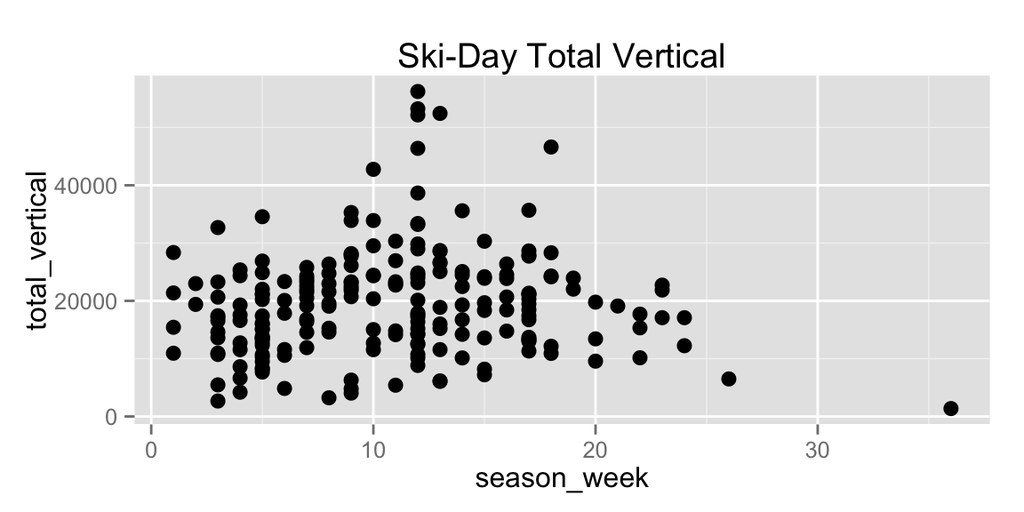

Another way to look at the data is as a histogram of daily total vertical for all ski days.

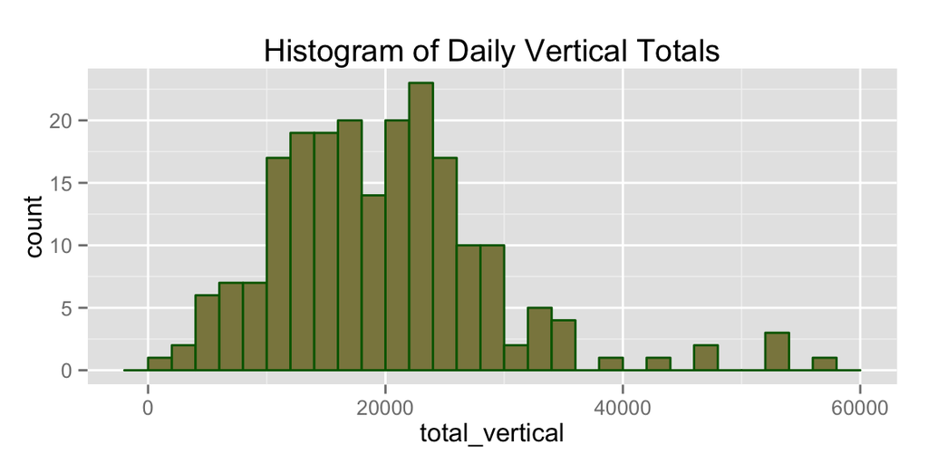

The mean vertical is 19691 feet over 211 days. The most frequent daily total is about 22000 feet / day.

## Visual Summary of Ski Seasons for MBXXXXXXXX

This is an interesting way to look at individual ski days. Vertical feet for the day are encoded in color, with red representing the highest dailty vert.

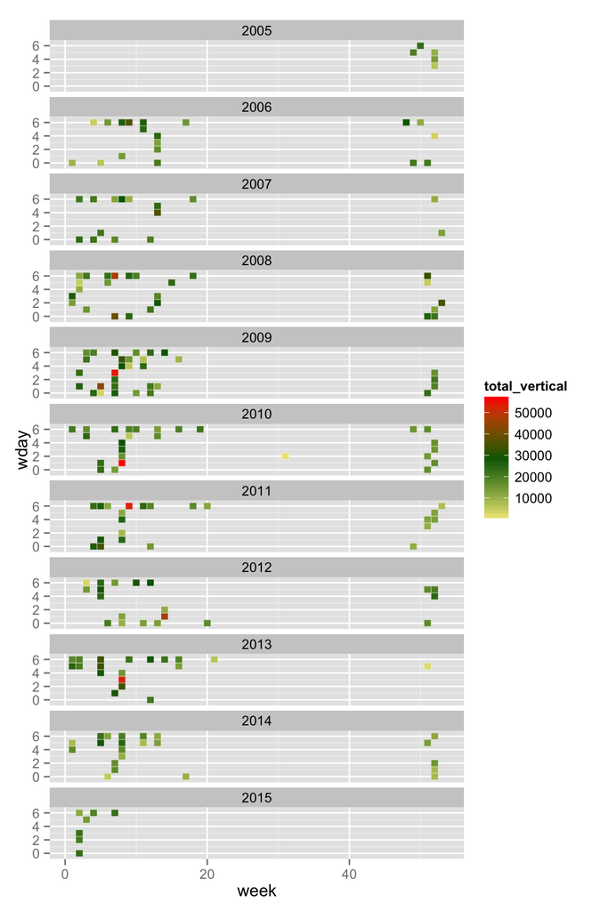

While interesting, this is not a particularly useful way of looking at the data since it doesn’t seem to provide much insight.

#### Chair lift totals

Here we begin to look at the data in somewhat finer detail. For instance we can look at the total vertical feet skied on a particular chairlift per ski day.

For the Pine Marten chair lift. OOps

```r
Pine_runs <- ski_runs[ski_runs$chair=="Pine Marten",]
```

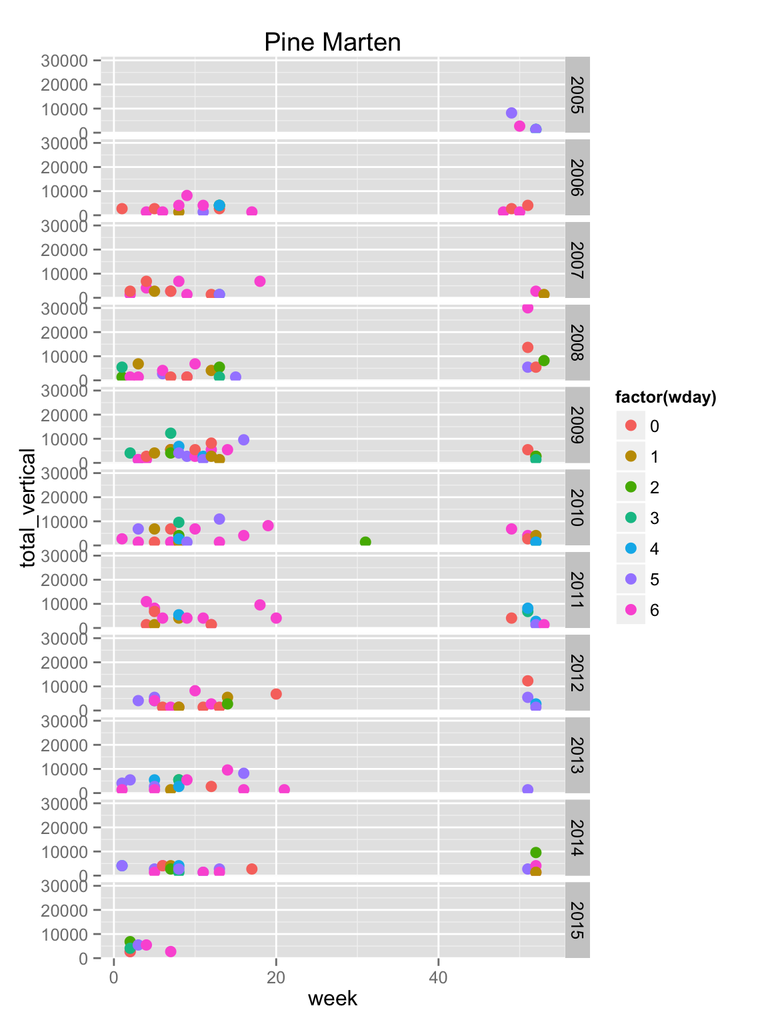

```r
Sunrise_runs <- ski_runs[ski_runs$chair=="Sunrise",]
```

### Sunrise Chairlift z-statistics

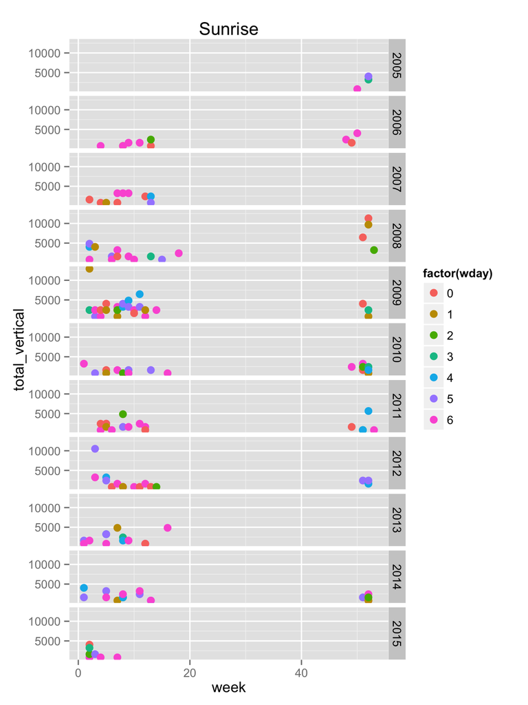

And as a last version, let’s just look at all of the sunrise totals. But rather than look at just the numbers, let’s look at the z-statistic for totals to look for outliers. Now this is starting to look likesomething useful…

```
##            total_vertical       date week season_week wday year count
## 2005-12-10            808 2005-12-10   50           6    6 2005     1
## 2005-12-28           3232 2005-12-28   52           9    3 2005     2
## 2005-12-30           4040 2005-12-30   52           9    5 2005     3
## 2006-01-28            808 2006-01-28    4          13    6 2006     4
## 2006-02-20            808 2006-02-20    8          16    1 2006     5
## 2006-02-25            808 2006-02-25    8          17    6 2006     6
```

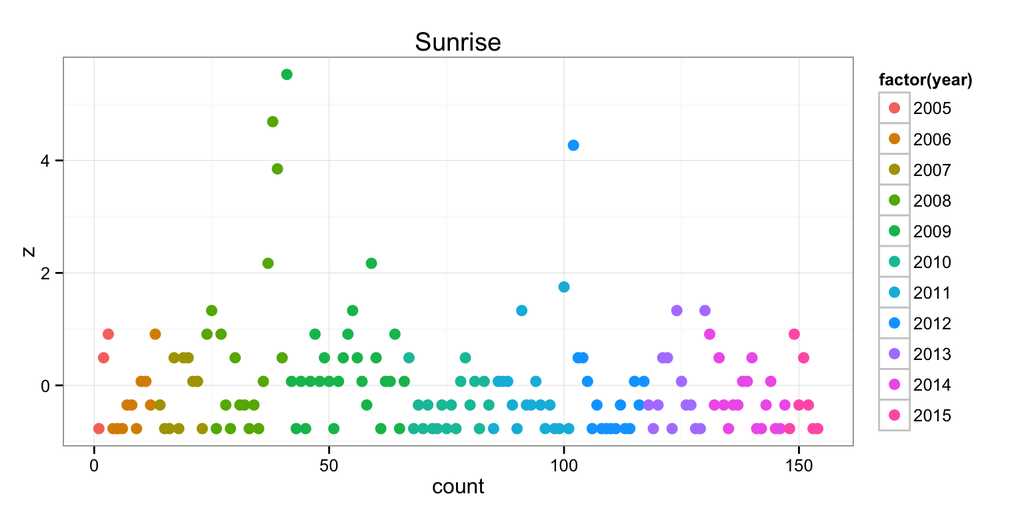

We can see, however, that the distribution has a very long tail.

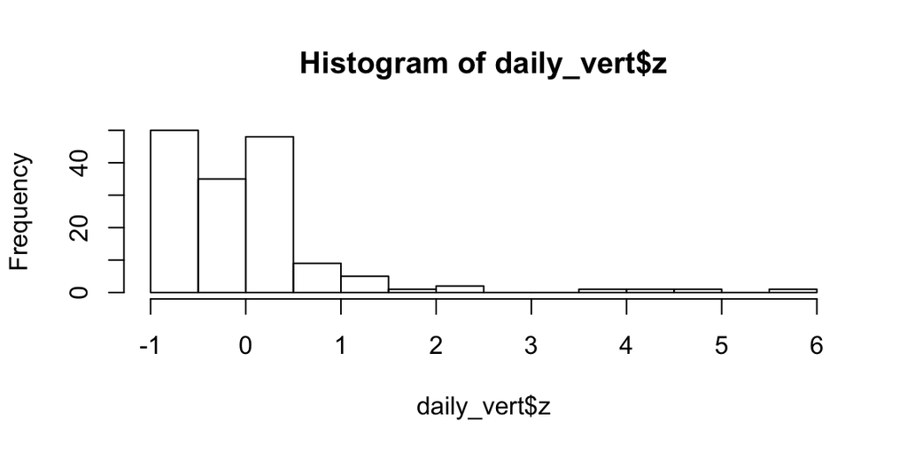

This seems like we might be getting somewhere. This analysis emphasizes there were a couple of anomalous days in the 2008-2009 season..

### Chairlift Usage

We can look if there are patterns in the charilift usage by looking for trends and patterns in the data on which chairs are ridden…

#### Chairlift Frequency

First, let’s just look at the number of rides on all chairs

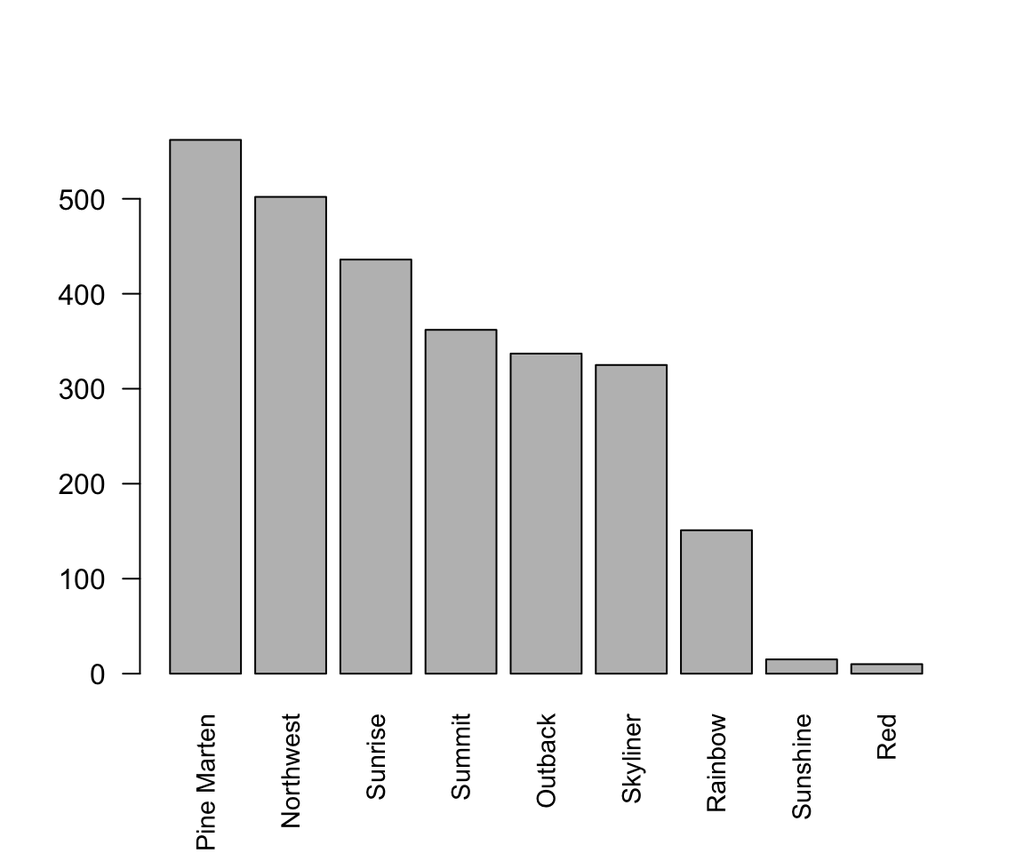

We can use this to test each day against this pattern…

```
## [1] 17.53247
```

```
##          Var1 Freq normalized_runs run_sq_dev average_runs   ski_date
## 1   Northwest    2           0.614   7.001316        3.260 2005-12-09
## 2     Outback    0           0.000   4.787344        2.188 2005-12-09
## 3 Pine Marten    6           1.644   4.020025        3.649 2005-12-09
## 4     Rainbow    0           0.000   0.962361        0.981 2005-12-09
## 5         Red    0           0.000   0.004225        0.065 2005-12-09
## 6    Skyliner    1           0.474   2.676496        2.110 2005-12-09
```

#### chair dev

```
##            run_sq_dev       date week season_day wday year season
## 2005-12-09   28.63136 2005-12-09   49          9    5 2005  05-06
## 2005-12-10   28.91979 2005-12-10   50         10    6 2005  05-06
## 2005-12-28  141.40010 2005-12-28   52         28    3 2005  05-06
## 2005-12-29   42.01020 2005-12-29   52         29    4 2005  05-06
## 2005-12-30   33.95522 2005-12-30   52         30    5 2005  05-06
## 2006-01-01   37.20077 2006-01-01    1         32    0 2006  05-06
```

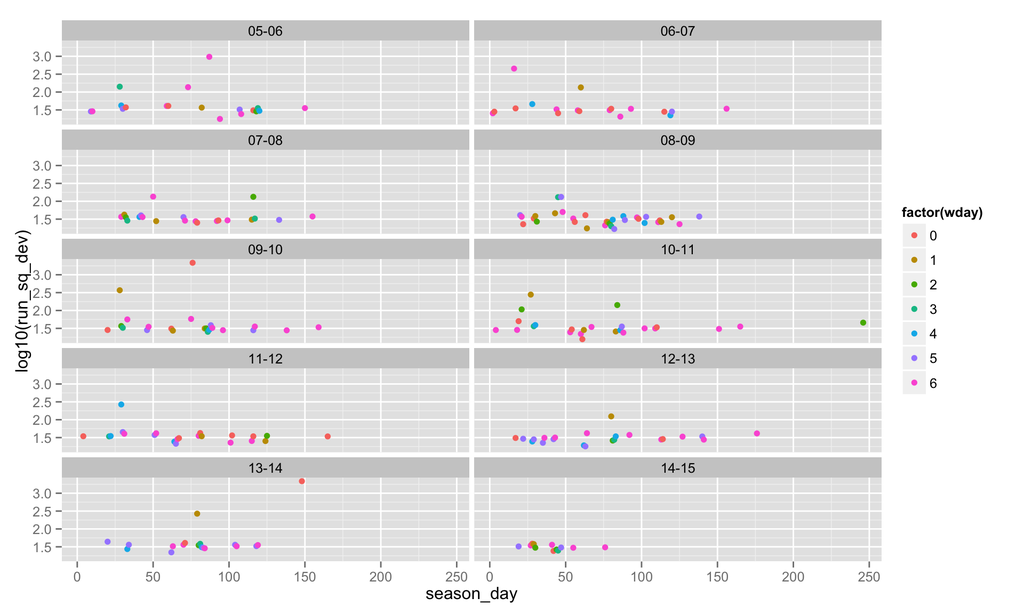

### Visualizing Chair Rides Per Day

Let’s explore graphically how frequently chairlifts are used throughout the season.

```
## [1] "Run list"
```

```
##           Var1 Freq normalized_runs run_sq_dev average_runs   ski_date
## 1    Northwest    2           0.614   7.001316        3.260 2005-12-09
## 2      Outback    0           0.000   4.787344        2.188 2005-12-09
## 3  Pine Marten    6           1.644   4.020025        3.649 2005-12-09
## 4      Rainbow    0           0.000   0.962361        0.981 2005-12-09
## 5          Red    0           0.000   0.004225        0.065 2005-12-09
## 6     Skyliner    1           0.474   2.676496        2.110 2005-12-09
## 7       Summit    3           1.276   1.155625        2.351 2005-12-09
## 8      Sunrise    0           0.000   8.014561        2.831 2005-12-09
## 9     Sunshine    0           0.000   0.009409        0.097 2005-12-09
## 10   Northwest    3           0.920   5.475600        3.260 2005-12-10
## 11     Outback    5           2.285   0.009409        2.188 2005-12-10
## 12 Pine Marten    2           0.548   9.616201        3.649 2005-12-10
##    season week season_day wday year
## 1   05-06   49         39    5 2005
## 2   05-06   49         39    5 2005
## 3   05-06   49         39    5 2005
## 4   05-06   49         39    5 2005
## 5   05-06   49         39    5 2005
## 6   05-06   49         39    5 2005
## 7   05-06   49         39    5 2005
## 8   05-06   49         39    5 2005
## 9   05-06   49         39    5 2005
## 10  05-06   50         40    6 2005
## 11  05-06   50         40    6 2005
## 12  05-06   50         40    6 2005
```

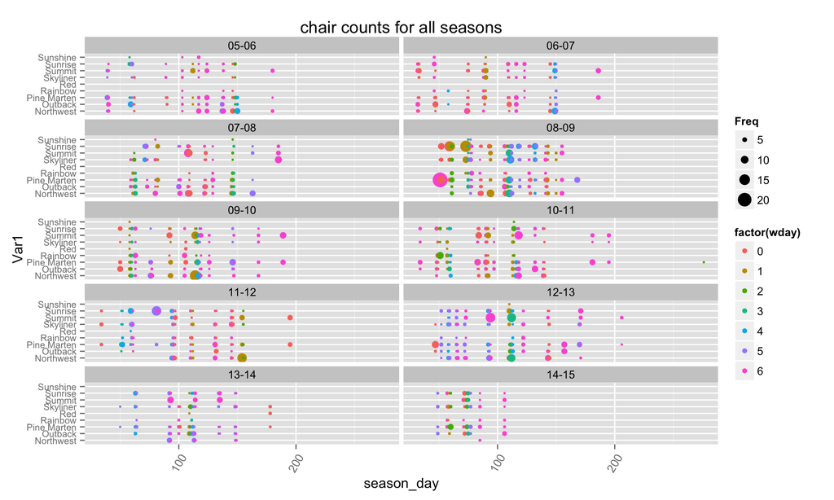

Let’s zoom in on a couple of seasons for fun.

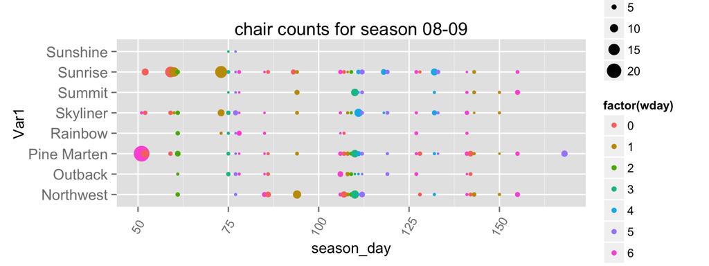

as an alternative way to look at things, let’s try this

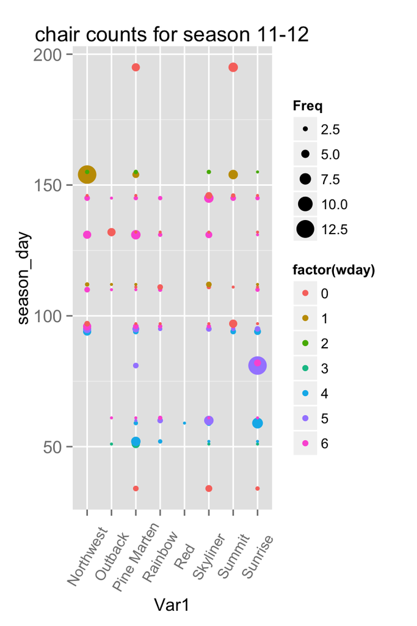

[figure not shown]